# ANOVA Power Analysis in R

Andrew East

January 29, 2019

# How large of a sample size do you need?

The traditional use of a power test is to solve for a sample size that will allow a certain amount of power given a number of treatments, sample sizes, and effect size. Using the `pwr.anova.test()` function in the `pwr` package, it looks something like this:

```r
pwr.anova.test(k=5,               # k is the number of groups
               n=NULL,            # n is the sample size for each group
               f=0.25,            # f is Cohen's f (1988), for effect size
               sig.level=0.05,    # sig.level is the selected alpha for your hypothesis test
               power=0.8)         # power is the desired level of power (beta)
```

```
##
##      Balanced one-way analysis of variance power calculation
##
##               k = 5
##               n = 39.1534
##               f = 0.25
##       sig.level = 0.05
##           power = 0.8
##
## NOTE: n is number in each group
```

In this case, we left the sample size blank (`n=NULL`) and the results in the R console tell us that a sample size of 39.15 would allow detection of a 0.25 effect size with 0.8 power, 0.05 alpha, across 5 groups.

Below you can see how sample size influences power across a range of sample sizes.

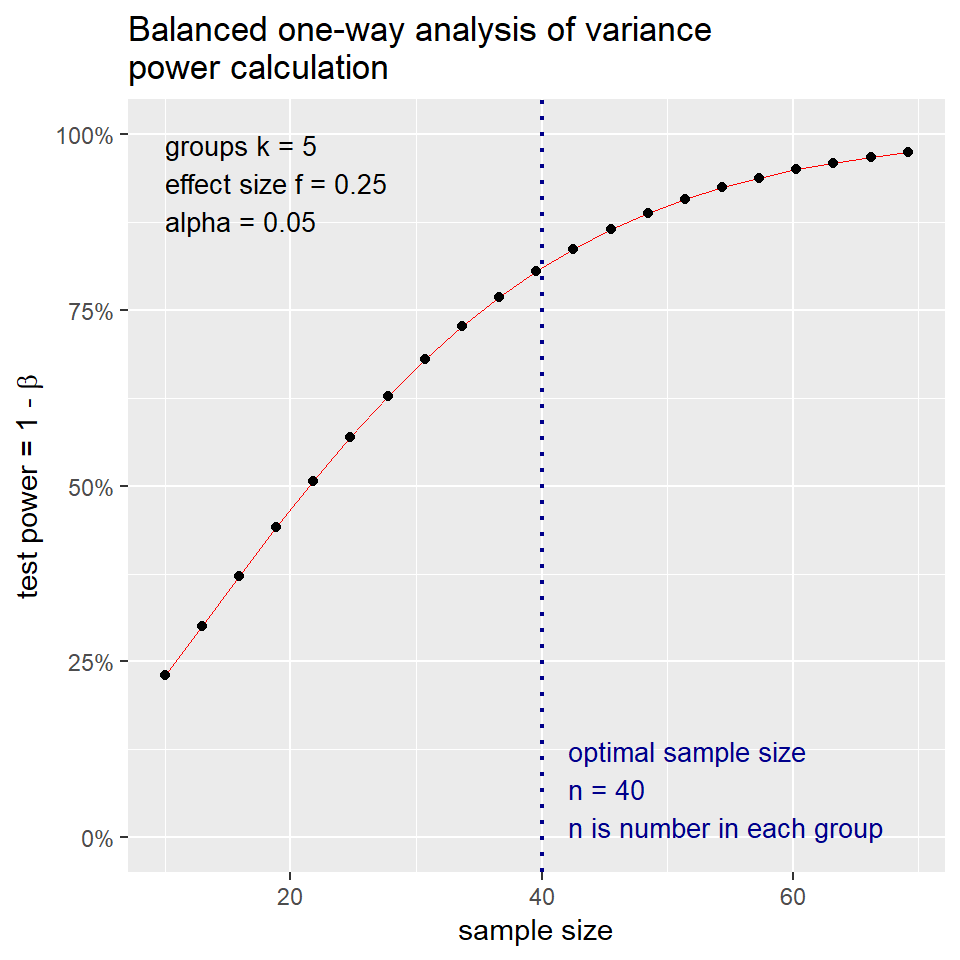

```r
pwrobj <- pwr.anova.test(k=5,
                         n=NULL,
                         f=0.25,
                         sig.level=0.05,
                         power=0.8)
plot(pwrobj)
```

Using this plot-based approach, we can explore other combinations of power and effect size. If we accept a lower power level we see that optimal sample size is reduced:

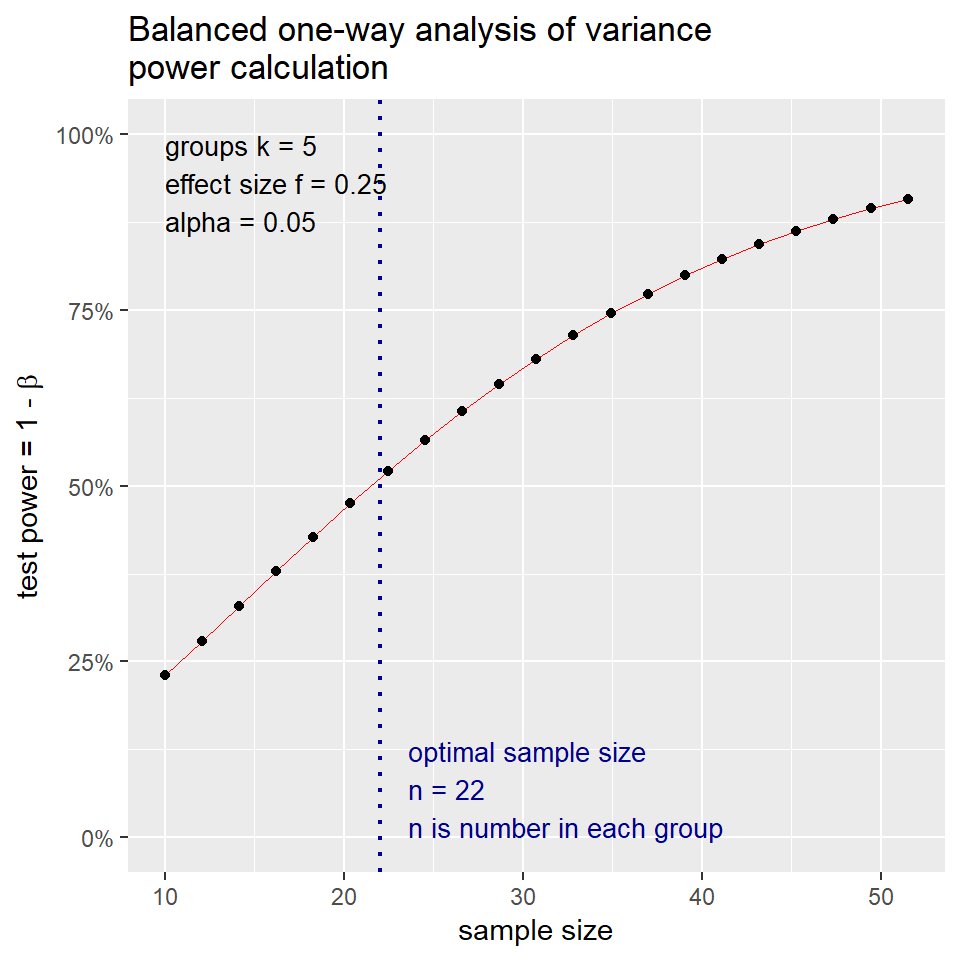

Alternatively, if we expect our data to show a larger effect size, we can see that reducing sample size would retain high power:

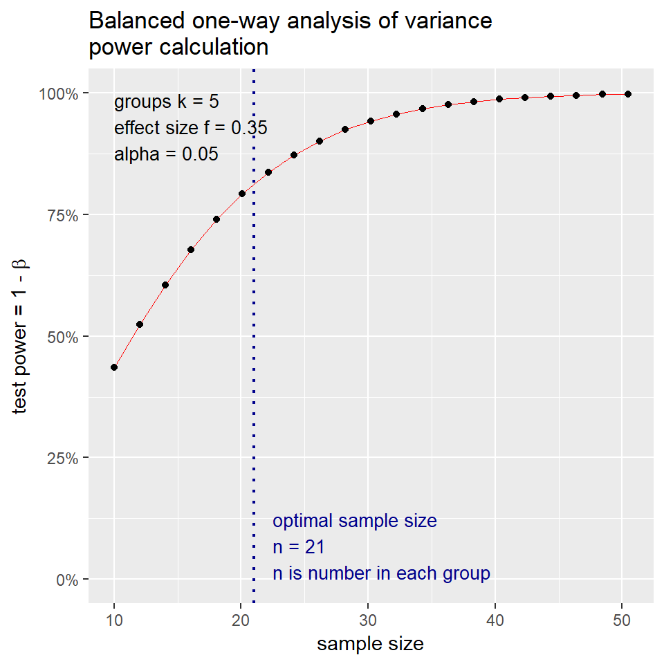

# Ok, but what does effect size mean?

The key here is that effect size does not relate to the size of the “effect” we’re measuring with our hypothesis test or experiment. The simplest description I’ve read for between group effect size is the proportion of the overall variation in the data that is explained by the treatments. There are several ways to quantify this (see Cohen 1988 for the “diety of power tests”), and they all require making up some fake data to play with.

## Make up data

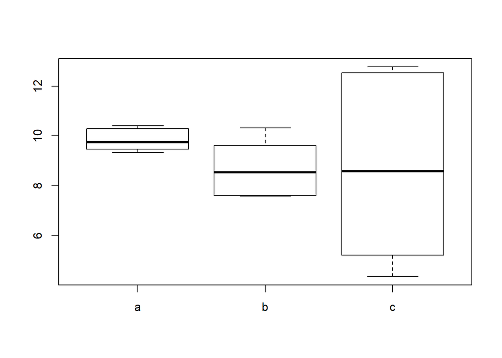

```
##         resp treat
## 1   9.466453     a
## 2  10.013782     a
## 3   9.334493     a
## 4  10.291585     a
## 5   9.498932     a
## 6  10.403100     a
## 7  10.322454     b
## 8   9.093076     b
## 9   7.607220     b
## 10  7.989680     b
## 11  9.615117     b
## 12  7.585716     b
## 13 12.540009     c
## 14  9.937823     c
## 15  4.365036     c
## 16  7.227543     c
## 17 12.766837     c
## 18  5.219936     c
```

```r
## Make fake data to see what effect sizes look like
set.seed(101987)                                       # make your random numbers the same
                                                       # as mine for this R session (close after done!!)
resp <- c(rnorm(n=6,mean=10,sd=1),
          rnorm(n=6,mean=9,sd=1),
          rnorm(n=6,mean=10,sd=2))                     # build response vector
treat <- c(rep("a",6),rep("b",6),rep("c",6))           # build treatment vector
df <- data.frame(resp=resp,treat=treat)                # combine vectors into dataframe
df                                                     # look at dataframe
boxplot(resp~factor(treat), data=df)                   # look at boxplot of same data
```

```r
## to calculate Cohen's f
grandmean <- mean(df$resp)                              # the mean resp of the df
a <- mean(df$resp[df$treat=="a"])                       # group means of df
b <- mean(df$resp[df$treat=="b"])
c <- mean(df$resp[df$treat=="c"])
leng <- length(unique(df$treat))                        # number of groups
sigma_m <- sqrt((sum((c(a,b,c)-grandmean)^2))/leng)     # see Cohen 88, page 275, but essentially
                                                        # the sum of the squared mean
                                                        # differences divded by number of groups and
                                                        #sqaure rooted (similar to sum of
                                                        # squares in an ANOVA)
sigma <- sd(df$resp)                                    # overall sd for response
f <- sigma_m/sigma                                      # Cohen's f for this particular ANOVA test.
f                                                       # the somewhat small size indicates that
                                                        # there is little effect of the
                                                        # treatment
```

```
## [1] 0.2509257
```

This value is useful in helping determine how “large” the effect is–this is made more clear by looking at actual ANOVA output:

```r
## also, to calculate Cohen's n^2
aov1 <- aov(resp~factor(treat), data=df)               # create ANOVA object with resp explained by
                                                       # factorized treatment in df dataframe
aov1                                                   # look at ANOVA object
summary(aov1)                                          # see summary, including p-value, of ANOVA object
sumobj <- unlist(summary(aov1))                        # change the structure of the anova summary object
aoveff <- sumobj["Sum Sq1"]/sumobj["Sum Sq2"]          # the treatment sum of squares / residual sum of squares
aoveff
```

```
## Call:
##    aov(formula = resp ~ factor(treat), data = df)
##
## Terms:
##                 factor(treat) Residuals
## Sum of Squares         5.2509   73.5116
## Deg. of Freedom             2        15
##
## Residual standard error: 2.213769
## Estimated effects may be unbalanced
##               Df Sum Sq Mean Sq F value Pr(>F)
## factor(treat)  2   5.25   2.625   0.536  0.596
## Residuals     15  73.51   4.901
##   Sum Sq1
## 0.0714295
```

The ratio between treatment sum of squares and total (residuals) sum of squares is the proportion of the variation explained by the treatments.  
In this case, ~7% of the variation is explained by the treatment. This value is relatively small, which corroborates with our interpretation above from the f value that the treatment effect is relatively small in this dataset.

An additional effect size metric from Cohen (88) is ‘d.’ This value relates the range in means to the standard deviation of the response vector.

```r
d <- (max(c(a,b,c))-min(c(a,b,c)))/sigma      # using the maximum mean and minimum mean
d                                             # this d suggests small to intermediate effects
```

```
## [1] 0.5382337
```

Interpretation of this value requires comparison to tables–0.5 corresponds with low end intermediate effect size.

# Ok, now that effect size makes sense, what about power?

If we take the above fake data and run it through the `pwr.anova.test()` function, we see that power (beta) is very low.

```r
pwr.anova.test(n=6,k=3,f=0.25,sig.level=0.05)
```

```
##
##      Balanced one-way analysis of variance power calculation
##
##               k = 3
##               n = 6
##               f = 0.25
##       sig.level = 0.05
##           power = 0.1260678
##
## NOTE: n is number in each group
```

## Why is this?

Think about alpha–we use a very small value (0.05) as our cut-off as it represents the likelihood that we would make a type I error (“a false positive” or failure to accept the correct null hypothesis). This is bad and we want to avoid it. Beta (power) is the converse–type II error (a “false negative” or failure to reject the incorrect null hypothesis), this is also bad, but much harder to wrap your brain around. The wikipedia example for type II error is a blood test failing to detect a compound it was designed to detect. The same example for type I error is detecting a disease when the patient doesn’t actually have it. Assuming the treatment is not catastrophic, this is less bad than not detecting the disease (type II) which would lead to death.

In our fake data, why would we not be confident in our ANOVA explaining the difference between treatment groups below:

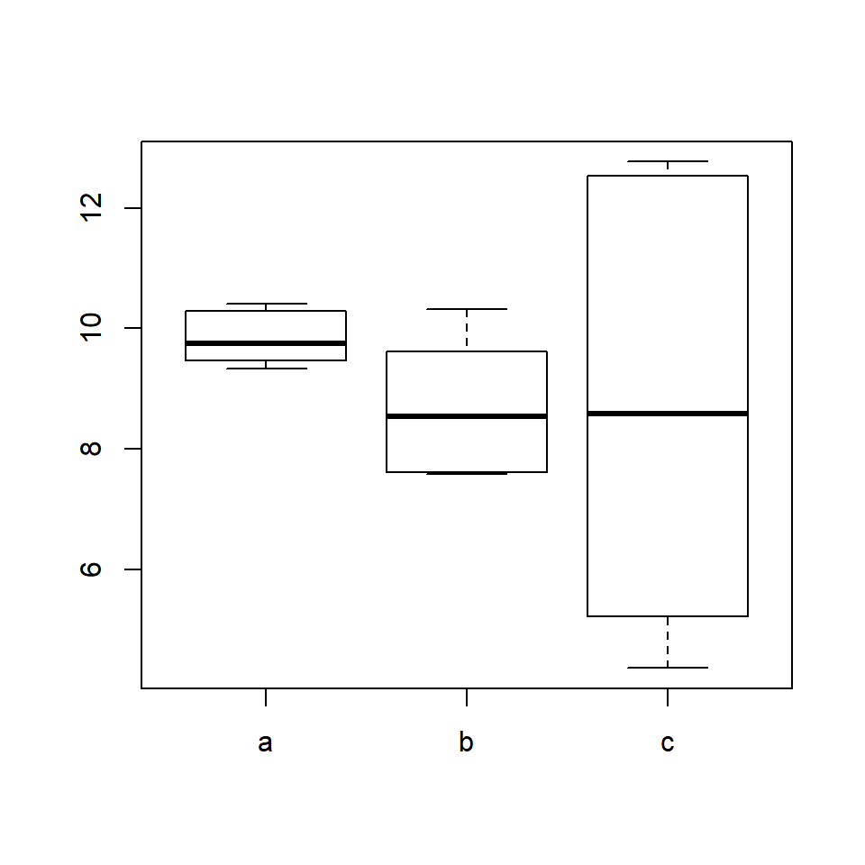

## Let’s explore another example using fake data

In this dataset, I’ve evened the standard deviations and made the means more different…let’s see what happens to our effect size.

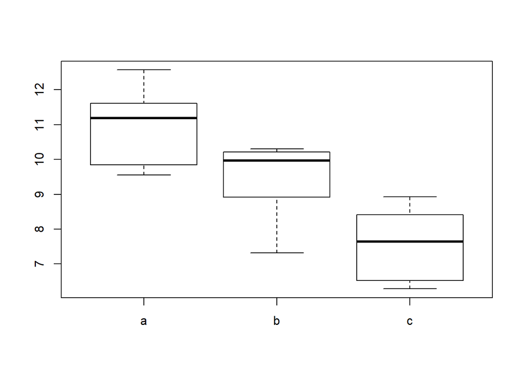

```
##         resp treat
## 1   9.843912     a
## 2   9.549310     a
## 3  12.568241     a
## 4  11.042070     a
## 5  11.333537     a
## 6  11.612060     a
## 7   7.317251     b
## 8   8.912502     b
## 9  10.217079     b
## 10 10.304529     b
## 11  9.905692     b
## 12 10.031464     b
## 13  8.418184     c
## 14  8.926861     c
## 15  6.286124     c
## 16  8.310008     c
## 17  6.964100     c
## 18  6.518127     c
```

```r
## Make fake data to see what effect sizes look like
set.seed(10191987)                                   # make your random numbers the same as mine for this R session
resp2 <- c(rnorm(n=6,mean=10,sd=1),
          rnorm(n=6,mean=9,sd=1),
          rnorm(n=6,mean=8,sd=1))                   # build response vector
treat2 <- c(rep("a",6),rep("b",6),rep("c",6))         # build treatment vector
df2 <- data.frame(resp=resp2,treat=treat2)              # combine vectors into dataframe
df2                                                   # look at dataframe
boxplot(resp~factor(treat), data=df2)                 # look at boxplot of same data
```

Using these data the new Cohen’s f is 0.7809589, eta eta squared (n^2) is 1.823049, and Cohen’s d is 1.9099173.  
Clearly, the effect size is a lot larger–the treatment has more effect on the variation. Using the `pwr.anova.test()` function and this Cohen’s f value, our power is 0.7674155.  
Again, this is clearly better power with more effect size.